# Quantitative Genetics

Genotype-by-environment interaction – FA analyses

Felipe Ferrão

University of Florida – November, 2022

**Objectives:**

- 60 minutes of hands-on
- GxE interaction

**Extra information**

- [PCB 6555 – Website](https://lfelipe-ferrao.github.io/class/quantGenetic/)
- About the [author](https://lfelipe-ferrao.github.io/)
- About the [UF/IFAS Plant Breeding](https://programs.ifas.ufl.edu/plant-breeding/)

# Introduction

In the context of mixed models, we are discussing the importance on using different var-cov structures to model GxE interaction. However, when a large number of environments is presented, the number of parameters to be estimated grows quadratically with the number of trials so it quickly becomes too many parameters to estimate. For this reason, it is common to recall to var-cov matrices that are symmetric, so less parameters can be estimated. Among the main methods, Factor Analytic Model has its moment in the GxE literature given the high flexibility and meaningful results.

# Theory

## Factor Analytic (FA) Model

FA var-cov structures offer a more parsimonious approach to describe covariance among environments. As an example in trials with 5,10 and 50 environments we need to estimate 15, 55 and 1275 parameters using an unstructure form. On the other hand, FA models are used as parsimonious approximations to unstructured models and we need to estimate 10, 20 and 100 parameters to fit the same model.

Important advantages on using FA models:

- Ability to adequately capture the often complex variance structure without the use of an excessive number of variance parameters.
- In the case of a less than full rank variance structure for the G × E effects can be accommodated, provided that an appropriate estimation algorithm is implemented.

First important point when fitting a FA model is to realize that genetic and environment factors can be written as a latent variable arising from a multiplicative (or regression) model. Therefore, in a linear model, we need to replace our genetic term by a multiplicative additive genetic effect for individual i and environment j. We can write it as:

$$u_{a_{ij}} = \lambda_{a1}
f_{a1i}+\lambda_{a2} f_{a2i}+...+\lambda_{akj} f_{aki} +
\delta_{aij}$$

$$u_{ge_{ij}} = \sum^k_{l=1}
\lambda_{jl}f_{il} + \delta_{ij}$$

Where

- $\lambda_{jl}$ is the **loading for environment** represented as a l-th environmental covariate at the j-th environment and is called as the
- $f_{il}$ is the slope or the **score** for i-th genotype for the l-th environment covariate
- $\delta$ is the residual GxE.

Some important point:

- It is like a linear regression model except the covariates are estimated from the data.
- Loading represent some latent environmental covariate.

In a vector notation, we can write the same information as:

$$u_a = (I_m \otimes \Lambda_a)f_a +
\delta_a$$

where $\Lambda$ is the txk matrix of environment loading, $f_a$ is the mkx1 vector of additive genetic scores and $\sigma_a$ is the mtx1 vector of genetic regression residuals.

We can make some important extensions of this base model and present the genetic effects in terms of breeding values by additing a relationship matrix in its formulation. For example, we can assume that both $f_a$ and $\sigma_a$ are independent and are distributed as multivariate Gaussian with zero means and variance matrices given by:

$$var(f_a) = A \otimes I_k$$

$$var(\delta_a)= A \otimes
\Psi_a$$

where $\Psi_a$ is a $t \times t$ diagonal matrix diagonal matrix with a variance (known as a specific variance) for each environment. These assumptions lead to:

$$var(u_a) = G_a = A \otimes
(\Lambda_a\Lambda^T_a + \Psi_a)$$

As many multivariate analyses a key process is to maximize the variance in few components. For example, this is the central ideal underlying typical PCA analyses.Here, we have the same issue and the number of $k$ can change increasing the complexity of the models. How to define the best k? To determine an appropriate value of k , we use a measure similar to an R2 goodness-of-fit value for a multiple regression. This is partly driven by the fact that predicted breeding values for individual trials are based on the multiplicative terms alone, that is, the genetic regression residuals are excluded. In a matrix notation, we could use the following equation, in which we measure the percentage of additive genetic variance accounted for by the $k$ multiplicative terms:

$$v_{a_j}= 100 \dfrac{tr
\Lambda\Lambda^T}{tr (\Lambda\Lambda^T + \Psi)}$$
We choose an order such that the overall percentage variance accounted for is high and the number of trials with low individual v a j values is small.

# Hands on

### Pinus data set

| Effect | Observation | Levels |
| --- | --- | --- |
| site | location of the progeny test | 12 |
| block | replication number | 20 |
| female | GCA effect | 70 |
| height | response variable | numeric |

```r
# FA model
library(dplyr)
library(asreml)
# Download the data
data = read.csv("/home/lferrao/Dropbox (UFL)/classes/QuantitativeGenetics_22/Class11_GxE/polymix.csv",
                colClasses = c("factor", "factor", "factor", "factor",
                               "numeric", "numeric", "numeric", "numeric"))

# FA1
mm.FA1 = asreml(fixed = height ~ 1 + site ,
             random = ~ block:site + fa(site,1):female,
             residual=~dsum(~id(units)|site),
             data = data)
```

```
## Multi-section model using the sigma parameterization.
## ASReml 4.1.0 Tue Nov 29 12:37:46 2022
##           LogLik        Sigma2     DF     wall    cpu
##  1     -23971.77           1.0  15379 12:37:46    0.0
##  2     -23495.14           1.0  15379 12:37:46    0.0
##  3     -23068.32           1.0  15379 12:37:46    0.0 (2 restrained)
##  4     -22900.92           1.0  15379 12:37:46    0.0 (4 restrained)
##  5     -22876.37           1.0  15379 12:37:46    0.0 (4 restrained)
##  6     -22873.78           1.0  15379 12:37:46    0.0 (2 restrained)
##  7     -22873.54           1.0  15379 12:37:47    0.0
##  8     -22873.54           1.0  15379 12:37:47    0.0
```

```r
mm.FA1=update.asreml(mm.FA1)
```

```
## Multi-section model using the sigma parameterization.
## ASReml 4.1.0 Tue Nov 29 12:37:47 2022
##           LogLik        Sigma2     DF     wall    cpu
##  1     -22873.54           1.0  15379 12:37:47    0.0
##  2     -22873.54           1.0  15379 12:37:47    0.0
```

```r
summary(mm.FA1)$varcomp
```

```
##                              component  std.error    z.ratio bound %ch
## block:site                  0.93743213 0.09807585  9.5582366     P 0.0
## fa(site, 1):female!101!var  0.76875264 0.22622659  3.3981533     P 0.0
## fa(site, 1):female!102!var  0.08629417 0.04966533  1.7375132     P 0.0
## fa(site, 1):female!103!var  0.06628429 0.07943521  0.8344446     P 0.0
## fa(site, 1):female!104!var  0.00000000         NA         NA     F  NA
## fa(site, 1):female!105!var  0.43651009 0.16884927  2.5852057     P 0.0
## fa(site, 1):female!106!var  0.27598202 0.16311828  1.6919135     P 0.0
## fa(site, 1):female!107!var  0.00000000         NA         NA     F  NA
## fa(site, 1):female!108!var  0.00000000         NA         NA     F  NA
## fa(site, 1):female!109!var  0.12904959 0.09022387  1.4303264     P 0.0
## fa(site, 1):female!110!var  0.00000000         NA         NA     F  NA
## fa(site, 1):female!112!var  0.12710534 0.13245934  0.9595801     P 0.0
## fa(site, 1):female!113!var  0.01236019 0.05297029  0.2333420     P 0.2
## fa(site, 1):female!101!fa1  0.82266600 0.15068738  5.4594220     P 0.0
## fa(site, 1):female!102!fa1  0.67878112 0.07892765  8.6000423     P 0.0
## fa(site, 1):female!103!fa1  0.71992694 0.09398960  7.6596445     P 0.0
## fa(site, 1):female!104!fa1  0.74329658 0.08934043  8.3198235     P 0.0
## fa(site, 1):female!105!fa1  0.44188426 0.12552735  3.5202230     P 0.0
## fa(site, 1):female!106!fa1  0.70495015 0.12477965  5.6495605     P 0.0
## fa(site, 1):female!107!fa1  0.93502315 0.10009706  9.3411647     P 0.0
## fa(site, 1):female!108!fa1  0.75605303 0.08139688  9.2884768     P 0.0
## fa(site, 1):female!109!fa1  0.80879023 0.10173403  7.9500462     P 0.0
## fa(site, 1):female!110!fa1  0.74679741 0.08958832  8.3358790     P 0.0
## fa(site, 1):female!112!fa1  0.98704968 0.12224024  8.0746706     P 0.0
## fa(site, 1):female!113!fa1  0.67592971 0.08187579  8.2555507     P 0.0
## site_101!R                  9.79896104 0.38855017 25.2192941     P 0.0
## site_102!R                  3.18767841 0.12777826 24.9469537     P 0.0
## site_103!R                  6.89019074 0.27558202 25.0023230     P 0.0
## site_104!R                  6.47994773 0.25040383 25.8779902     P 0.0
## site_105!R                  8.95899023 0.38169768 23.4714298     P 0.0
## site_106!R                 11.42415817 0.46886957 24.3653222     P 0.0
## site_107!R                  6.76792700 0.27748908 24.3898855     P 0.0
## site_108!R                  4.83502212 0.19098594 25.3161151     P 0.0
## site_109!R                  6.79924458 0.26846141 25.3267110     P 0.0
## site_110!R                  5.86900659 0.25115118 23.3684210     P 0.0
## site_112!R                  9.33016198 0.40530100 23.0203283     P 0.0
## site_113!R                  5.46108211 0.21799063 25.0519121     P 0.0
```

```r
# Extracting some information from FA model
lambda = summary(mm.FA1)$varcomp[grep('fa1',rownames(summary(mm.FA1)$varcomp)),1]
psi = diag(summary(mm.FA1)$varcomp[grep('var',rownames(summary(mm.FA1)$varcomp)),1])
Gvcov = lambda %*% t(lambda) + psi
Gvcov[1:5,1:5] # covariance/variance/correlation matrix
```

```
##           [,1]      [,2]      [,3]      [,4]      [,5]
## [1,] 1.4455320 0.5584102 0.5922594 0.6114848 0.3635232
## [2,] 0.5584102 0.5470380 0.4886728 0.5045357 0.2999427
## [3,] 0.5922594 0.4886728 0.5845791 0.5351192 0.3181244
## [4,] 0.6114848 0.5045357 0.5351192 0.5524898 0.3284511
## [5,] 0.3635232 0.2999427 0.3181244 0.3284511 0.6317718
```

```r
expvar1 = (sum(diag(lambda %*% t(lambda)))/sum(diag(lambda %*% t(lambda) + psi)))*100
expvar1
```

```
## [1] 78.60556
```

```r
# FA2
mm.FA2 = asreml(fixed = height ~ 1 + site ,
             random = ~ block:site + fa(site,2):female,
             residual=~dsum(~id(units)|site),
             data = data)
```

```
## Multi-section model using the sigma parameterization.
## ASReml 4.1.0 Tue Nov 29 12:37:47 2022
##           LogLik        Sigma2     DF     wall    cpu
##  1     -23950.20           1.0  15379 12:37:47    0.1
##  2     -23477.05           1.0  15379 12:37:47    0.1 (1 restrained)
##  3     -23055.01           1.0  15379 12:37:48    0.1 (3 restrained)
##  4     -22891.95           1.0  15379 12:37:48    0.1 (6 restrained)
##  5     -22867.27           1.0  15379 12:37:48    0.1 (5 restrained)
##  6     -22864.62           1.0  15379 12:37:48    0.1 (5 restrained)
##  7     -22864.34           1.0  15379 12:37:48    0.1 (1 restrained)
##  8     -22864.28           1.0  15379 12:37:48    0.1 (1 restrained)
##  9     -22864.27           1.0  15379 12:37:48    0.1
## 10     -22864.27           1.0  15379 12:37:48    0.1
## 11     -22864.27           1.0  15379 12:37:48    0.1
```

```r
mm.FA2=update.asreml(mm.FA2)
```

```
## Multi-section model using the sigma parameterization.
## ASReml 4.1.0 Tue Nov 29 12:37:48 2022
##           LogLik        Sigma2     DF     wall    cpu
##  1     -22864.27           1.0  15379 12:37:49    0.1
##  2     -22864.27           1.0  15379 12:37:49    0.1
```

```r
summary(mm.FA2)$varcomp
```

```
##                              component  std.error    z.ratio bound %ch
## block:site                  0.93758783 0.09808415  9.5590149     P 0.0
## fa(site, 2):female!101!var  0.71003121 0.22261373  3.1895212     P 0.0
## fa(site, 2):female!102!var  0.06543492 0.04844518  1.3507003     P 0.0
## fa(site, 2):female!103!var  0.06082936 0.07906990  0.7693112     P 0.0
## fa(site, 2):female!104!var  0.00000000         NA         NA     F  NA
## fa(site, 2):female!105!var  0.00000000         NA         NA     F  NA
## fa(site, 2):female!106!var  0.20121069 0.16040970  1.2543549     P 0.0
## fa(site, 2):female!107!var  0.00000000         NA         NA     F  NA
## fa(site, 2):female!108!var  0.00000000         NA         NA     F  NA
## fa(site, 2):female!109!var  0.10105740 0.08917226  1.1332829     P 0.0
## fa(site, 2):female!110!var  0.00000000         NA         NA     F  NA
## fa(site, 2):female!112!var  0.06292382 0.13062068  0.4817294     P 0.0
## fa(site, 2):female!113!var  0.00000000         NA         NA     F  NA
## fa(site, 2):female!101!fa1  0.85629775 0.15209824  5.6298993     P 0.0
## fa(site, 2):female!102!fa1  0.62120973 0.08930079  6.9563746     P 0.0
## fa(site, 2):female!103!fa1  0.66938927 0.10176925  6.5775201     P 0.0
## fa(site, 2):female!104!fa1  0.67391083 0.10558825  6.3824414     P 0.0
## fa(site, 2):female!105!fa1  0.26410861 0.15996619  1.6510277     P 0.1
## fa(site, 2):female!106!fa1  0.74949738 0.12584779  5.9555865     P 0.0
## fa(site, 2):female!107!fa1  0.90765386 0.10472883  8.6667051     P 0.0
## fa(site, 2):female!108!fa1  0.71921589 0.08765086  8.2054633     P 0.0
## fa(site, 2):female!109!fa1  0.82093019 0.10259952  8.0013066     P 0.0
## fa(site, 2):female!110!fa1  0.71202858 0.09487122  7.5052114     P 0.0
## fa(site, 2):female!112!fa1  1.01326269 0.12243488  8.2759316     P 0.0
## fa(site, 2):female!113!fa1  0.68379766 0.08178317  8.3611048     P 0.0
## fa(site, 2):female!101!fa2  0.00000000         NA         NA     F  NA
## fa(site, 2):female!102!fa2  0.31037028 0.11549443  2.6873182     P 0.0
## fa(site, 2):female!103!fa2  0.27760901 0.13397229  2.0721374     P 0.1
## fa(site, 2):female!104!fa2  0.36968459 0.13590622  2.7201447     P 0.0
## fa(site, 2):female!105!fa2  0.78591777 0.12758968  6.1597282     P 0.0
## fa(site, 2):female!106!fa2 -0.06425768 0.17510179 -0.3669733     P 0.5
## fa(site, 2):female!107!fa2  0.21887152 0.15422696  1.4191521     P 0.1
## fa(site, 2):female!108!fa2  0.23442566 0.12525879  1.8715306     P 0.1
## fa(site, 2):female!109!fa2  0.06962849 0.15118437  0.4605535     P 0.4
## fa(site, 2):female!110!fa2  0.22111258 0.13271264  1.6661003     P 0.1
## fa(site, 2):female!112!fa2  0.04942077 0.18622070  0.2653881     P 0.4
## fa(site, 2):female!113!fa2  0.06657548 0.12732267  0.5228878     P 0.0
## site_101!R                  9.79897937 0.38855268 25.2191783     P 0.0
## site_102!R                  3.18872704 0.12783399 24.9442813     P 0.0
## site_103!R                  6.89034819 0.27559699 25.0015363     P 0.0
## site_104!R                  6.44794814 0.24962568 25.8304683     P 0.0
## site_105!R                  8.92216723 0.37813803 23.5950014     P 0.0
## site_106!R                 11.42553907 0.46894859 24.3641614     P 0.0
## site_107!R                  6.76891069 0.27749618 24.3928070     P 0.0
## site_108!R                  4.83485379 0.19093750 25.3216566     P 0.0
## site_109!R                  6.79876688 0.26843554 25.3273721     P 0.0
## site_110!R                  5.87107952 0.25118126 23.3738758     P 0.0
## site_112!R                  9.33397097 0.40549932 23.0184628     P 0.0
## site_113!R                  5.45852182 0.21430674 25.4706024     P 0.0
```

As FA can be interpreted as a random regression, we can run some additional analyses and get the latent regression plots. To help on this task, we will use the `agriutilities` package and some functions that implemented there. The [agriutilities](https://github.com/AparicioJohan/agriutilities/) webpage has more details. But here, we will focus on few tasks:

- Create a heatmap to check the correlation between the environments
- Regplots: stability and performance
- Biplots

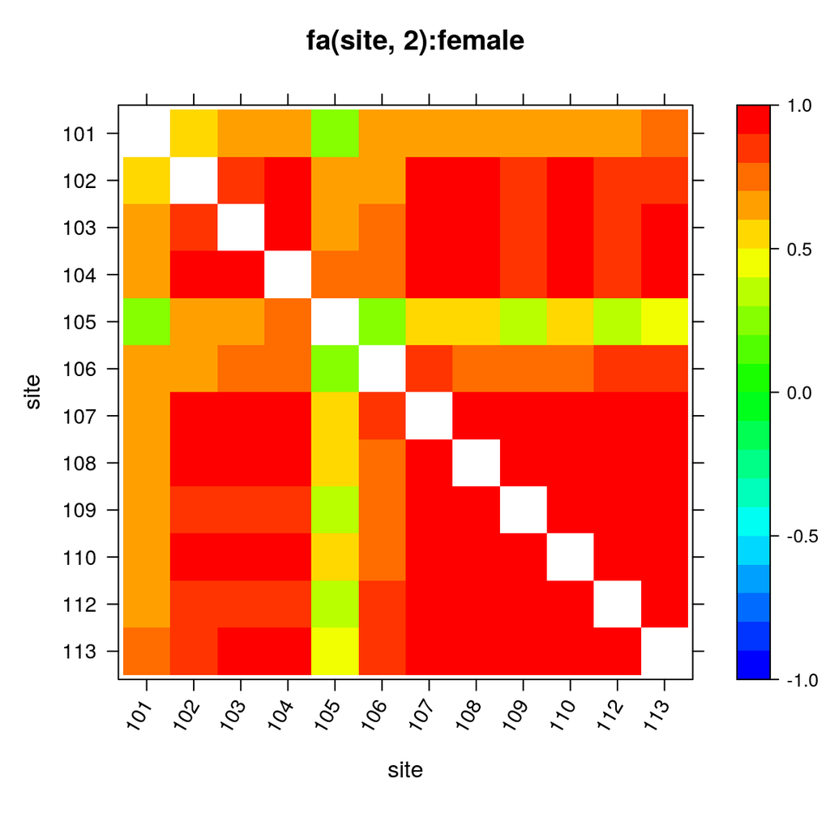

```r
library(agriutilities)
library(lattice)

# Latent Plots
ASM <- fa.asreml(mm.FA2,
                 regplot = T,
                 uniplot = T,
                 addedplot = T,
                 heatmap = T,
                 g.list = c("1", "117", "119", "122", "128"))
ASM$heatmaps$`fa(site, 2):female`
```

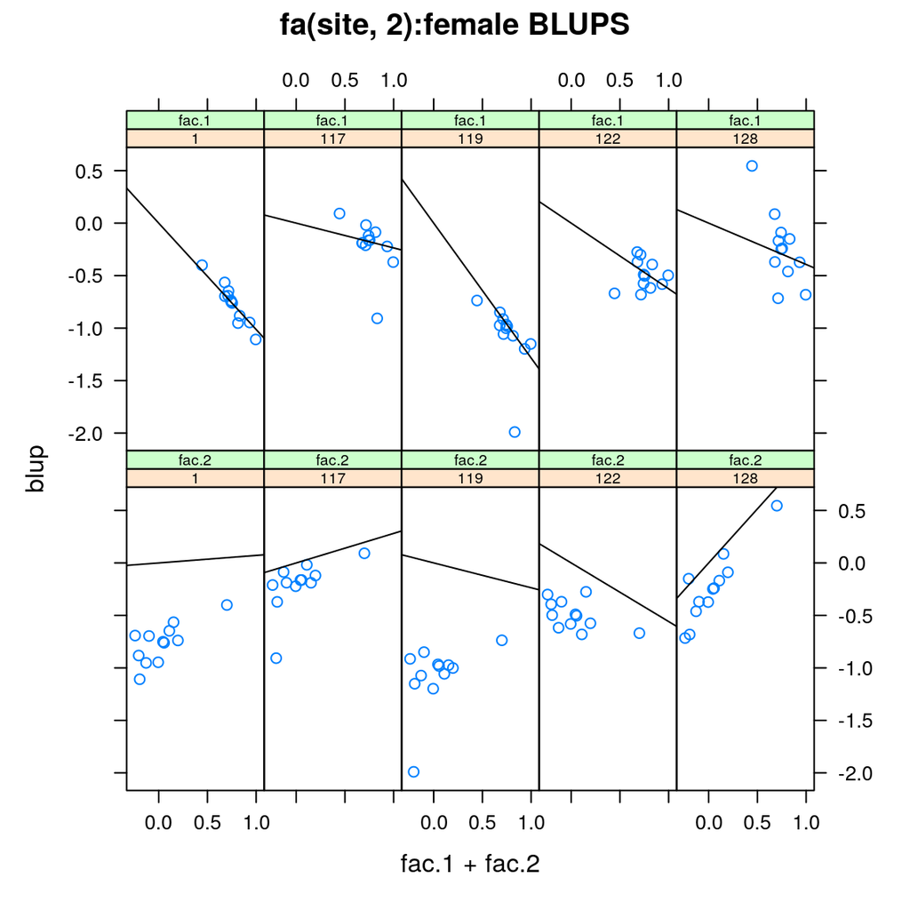

```r
ASM$regplots$`fa(site, 2):female`
```

```r
# Other summary
pp = predict(mm.FA2, classify = "site")$pvals
```

```
## Multi-section model using the sigma parameterization.
## ASReml 4.1.0 Tue Nov 29 12:37:50 2022
##           LogLik        Sigma2     DF     wall    cpu
##  1     -22864.27           1.0  15379 12:37:50    0.1
##  2     -22864.27           1.0  15379 12:37:50    0.1
##  3     -22864.27           1.0  15379 12:37:50    0.1
```

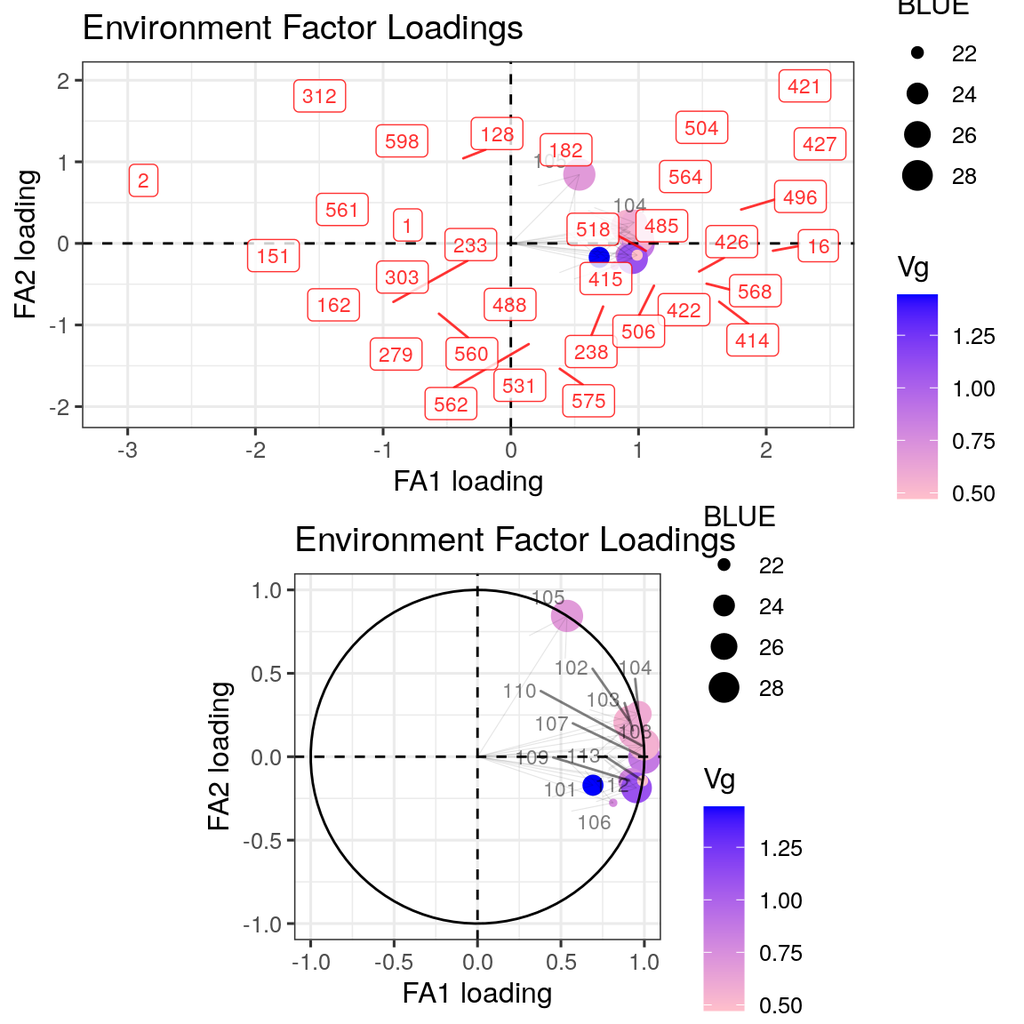

```r
fa.sum = fa2_summary(
    model = mm.FA2,
     trial = "site",
     genotype = "female",
     BLUEs_trial = pp,
   mult_fa1 = -1,
   mult_fa2 = -1,
   filter_score = 1,
   k_biplot = 10,
   size_label_var = 3,
   alpha_label_var = 0.5,
   size_label_ind = 3,
   alpha_label_ind = 0.8,
   size_arrow = 0.2,
   alpha_arrow = 0.1
)

p3 =  fa.sum$plots$biplot_scaled
p4 =  fa.sum$plots$loadings_c

library(gridExtra)
grid.arrange(p3,p4,ncol=1)
```

# References

- Smith et al. (2015) Factor analytic mixed models for the provision of grower information from national crop variety testing programs. Theoretical and Applied Genetics 128(1) 55-72
- Cullis et al. (2014) Factor analytic and reduced animal models for the investigation of additive genotype- by-environment interaction in outcrossing plant species with application to a Pinus radiata breeding programme. Theoretical and Applied Genetics 127(10) 2193-2210